# Predictive analysis of Bank Marketing

# VALIDATING MODELS

```python
def print_scores(y_test,y_pred,y_pred_prob):
    print("Accuracy score: \n", accuracy_score(y_test,y_pred))
    print('Test-set confusion matrix:\n', confusion_matrix(y_test,y_pred))
    print("Classification report:" "\n", classification_report(y_test,y_pred))
    print("ROC AUC: {}".format(roc_auc_score(y_test, y_pred_prob[:,1])))
```

**Use the Transformed dataset**

```
============================== DecisionTree Model Starts ==============================
Index(['age', 'job', 'marital', 'education', 'default', 'balance', 'housing',
       'loan', 'contact', 'day', 'month', 'duration', 'campaign', 'previous',
       'poutcome', 'Target'],
      dtype='object')
Train-set confusion matrix:
 [[31171   766]
 [ 2828  1403]]
============================== DecisionTree Model Evaluation ==============================
Accuracy score:
 0.8989273471193188
Test-set confusion matrix:
 [[7791  194]
 [ 720  338]]
Classification report:
               precision    recall  f1-score   support

           0       0.92      0.98      0.94      7985
           1       0.64      0.32      0.43      1058

   micro avg       0.90      0.90      0.90      9043
   macro avg       0.78      0.65      0.68      9043
weighted avg       0.88      0.90      0.88      9043

ROC AUC: 0.821563115150927
```

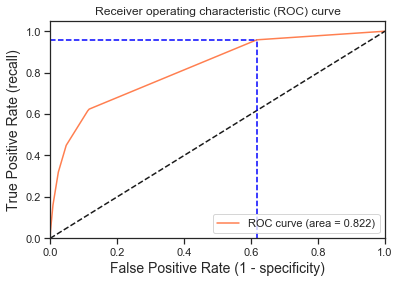

```
Using a threshold of 0.080 guarantees a sensitivity of 0.958 and a specificity of 0.383, i.e. a false positive rate of 61.70%.
============================== DecisionTree Model Ends ==============================


============================== RandomForest Model Starts ==============================
Index(['age', 'job', 'marital', 'education', 'default', 'balance', 'housing',
       'loan', 'contact', 'day', 'month', 'duration', 'campaign', 'previous',
       'poutcome', 'Target'],
      dtype='object')
Train-set confusion matrix:
 [[31928     9]
 [ 4192    39]]
============================== RandomForest Model Evaluation ==============================
Accuracy score:
 0.8842198385491541
Test-set confusion matrix:
 [[7981    4]
 [1043   15]]
Classification report:
               precision    recall  f1-score   support

           0       0.88      1.00      0.94      7985
           1       0.79      0.01      0.03      1058

   micro avg       0.88      0.88      0.88      9043
   macro avg       0.84      0.51      0.48      9043
weighted avg       0.87      0.88      0.83      9043

ROC AUC: 0.8789947006023818
```

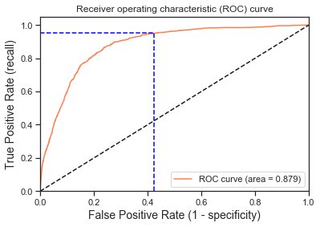

```
Using a threshold of 0.090 guarantees a sensitivity of 0.951 and a specificity of 0.576, i.e. a false positive rate of 42.37%.
============================== RandomForest Model Ends ==============================
```

```python
drop_list = [] #to drop columns not affecting the model output
models = []

models.append(('DecisionTree', DecisionTreeClassifier(criterion="entropy", max_depth=3)))
models.append(('RandomForest', RandomForestClassifier(criterion="entropy", max_depth=3)))

for i,v in models:
    print('============================== {} Model Starts =============================='.format(i))
    X_train, X_test, y_train, y_test = split_data(dfTransformed, drop_list)
    y_pred, y_pred_prob = get_predictions(v, X_train, y_train, X_test)
    print('============================== {} Model Evaluation =============================='.format(i))
    print_scores(y_test,y_pred,y_pred_prob)
    [fpr, tpr, thr] = roc_curve(y_test, y_pred_prob[:,1])
    roc_curve_draw(fpr, tpr, thr)
    print('============================== {} Model Ends =============================='.format(i))
    print('\n')
```

```
============================== GradientBoosting Model Starts ==============================
Index(['age', 'job', 'marital', 'education', 'default', 'balance', 'housing',
       'loan', 'contact', 'day', 'month', 'duration', 'campaign', 'previous',
       'poutcome', 'Target'],
      dtype='object')
Train-set confusion matrix:
 [[31476   461]
 [ 3138  1093]]
============================== GradientBoosting Model Evaluation ==============================
Accuracy score:
 0.8964945261528254
Test-set confusion matrix:
 [[7860  125]
 [ 811  247]]
Classification report:
               precision    recall  f1-score   support

           0       0.91      0.98      0.94      7985
           1       0.66      0.23      0.35      1058

   micro avg       0.90      0.90      0.90      9043
   macro avg       0.79      0.61      0.64      9043
weighted avg       0.88      0.90      0.87      9043

ROC AUC: 0.8823720160556241
```

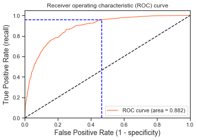

```
Using a threshold of 0.055 guarantees a sensitivity of 0.959 and a specificity of 0.535, i.e. a false positive rate of 46.52%.
============================== GradientBoosting Model Ends ==============================


============================== AdaBoosting Model Starts ==============================
Index(['age', 'job', 'marital', 'education', 'default', 'balance', 'housing',
       'loan', 'contact', 'day', 'month', 'duration', 'campaign', 'previous',
       'poutcome', 'Target'],
      dtype='object')
Train-set confusion matrix:
 [[30946   991]
 [ 2819  1412]]
============================== AdaBoosting Model Evaluation ==============================
Accuracy score:
 0.8937299568727193
Test-set confusion matrix:
 [[7731  254]
 [ 707  351]]
Classification report:
               precision    recall  f1-score   support

           0       0.92      0.97      0.94      7985
           1       0.58      0.33      0.42      1058

   micro avg       0.89      0.89      0.89      9043
   macro avg       0.75      0.65      0.68      9043
weighted avg       0.88      0.89      0.88      9043

ROC AUC: 0.8915455846441755
```

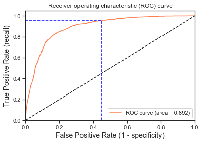

```
Using a threshold of 0.457 guarantees a sensitivity of 0.955 and a specificity of 0.554, i.e. a false positive rate of 44.62%.
============================== AdaBoosting Model Ends ==============================
```

```python
drop_list = [] #to drop columns not affecting the model output
models = []

models.append(('GradientBoosting', GradientBoostingClassifier(n_estimators=20, max_depth=3)))
models.append(('AdaBoosting', AdaBoostClassifier(n_estimators=20)))

for i,v in models:
    print('============================== {} Model Starts =============================='.format(i))
    X_train, X_test, y_train, y_test = split_data(dfTransformed, drop_list)
    y_pred, y_pred_prob = get_predictions(v, X_train, y_train, X_test)
    print('============================== {} Model Evaluation =============================='.format(i))
    print_scores(y_test,y_pred,y_pred_prob)
    [fpr, tpr, thr] = roc_curve(y_test, y_pred_prob[:,1])
    roc_curve_draw(fpr, tpr, thr)
    print('============================== {} Model Ends =============================='.format(i))
    print('\n')
```

**Summary** - When we used default regularization parameters, and considered all feature, we found that Best performer is Ada Boosting Algo, which has ROC = 89% and the FN and TN are less compared to other ensemble models. Also the recall and precision is 97% and 92% respectively for this Ada Boosting with ROC = 89%

Worst performer is Random Forest where the Recall = 1 and all are predicted as TN.

# Feature Importance using Random Forest

```python
X_train, X_test, y_train, y_test = split_data(dfTransformed, drop_list)
model = RandomForestClassifier()

#thit is how we get the feature importance with simple steps:
model.fit(X_train, y_train)
# display the relative importance of each attribute
importances = model.feature_importances_
#Sort it
print ("Sorted Feature Importance:")
# feature_imp = pd.Series(importances,index=dfTransformed.columns).sort_values(ascending=False)
# feature_imp
sorted_feature_importance = sorted(zip(importances, list(dfTransformed.columns)), reverse=True)
print (sorted_feature_importance)
df = pd.DataFrame(sorted_feature_importance, columns=['Score','Features'])
```

[output not shown]

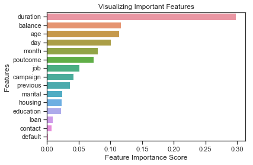

```python
sns.barplot(x=df.Score, y=df.Features)
# Add labels to your graph
plt.xlabel('Feature Importance Score')
plt.ylabel('Features')
plt.title("Visualizing Important Features")
plt.show()
```

**We can see that duration is the highest contributor followed by balance, age, day and month. Rest all dont have much effect of defining the tree.**

We can remove atleast columns default, contact, loan, marital, education, and housing

```
============================== DecisionTree Model Starts ==============================
Index(['age', 'job', 'balance', 'day', 'month', 'duration', 'campaign',
       'previous', 'poutcome', 'Target'],
      dtype='object')
Train-set confusion matrix:
 [[31171   766]
 [ 2828  1403]]
============================== DecisionTree Model Evaluation ==============================
Accuracy score:
 0.8989273471193188
Test-set confusion matrix:
 [[7791  194]
 [ 720  338]]
Classification report:
               precision    recall  f1-score   support

           0       0.92      0.98      0.94      7985
           1       0.64      0.32      0.43      1058

   micro avg       0.90      0.90      0.90      9043
   macro avg       0.78      0.65      0.68      9043
weighted avg       0.88      0.90      0.88      9043

ROC AUC: 0.821563115150927
```

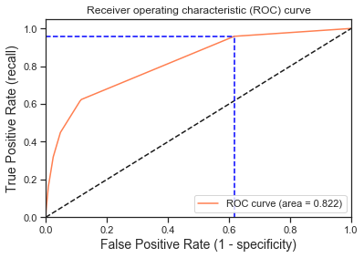

```
Using a threshold of 0.080 guarantees a sensitivity of 0.958 and a specificity of 0.383, i.e. a false positive rate of 61.70%.
============================== DecisionTree Model Ends ==============================


============================== RandomForest Model Starts ==============================
Index(['age', 'job', 'balance', 'day', 'month', 'duration', 'campaign',
       'previous', 'poutcome', 'Target'],
      dtype='object')
Train-set confusion matrix:
 [[31707   230]
 [ 3544   687]]
============================== RandomForest Model Evaluation ==============================
Accuracy score:
 0.8963839433816212
Test-set confusion matrix:
 [[7928   57]
 [ 880  178]]
Classification report:
               precision    recall  f1-score   support

           0       0.90      0.99      0.94      7985
           1       0.76      0.17      0.28      1058

   micro avg       0.90      0.90      0.90      9043
   macro avg       0.83      0.58      0.61      9043
weighted avg       0.88      0.90      0.87      9043

ROC AUC: 0.861325287371288
```

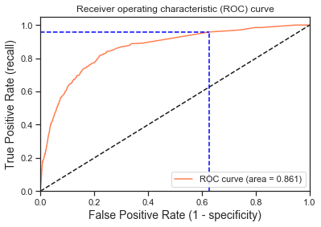

```
Using a threshold of 0.062 guarantees a sensitivity of 0.958 and a specificity of 0.373, i.e. a false positive rate of 62.72%.
============================== RandomForest Model Ends ==============================
```

```python
drop_list = ['default','contact','loan','marital','education','housing']
#to drop columns not affecting the model output

models = []

models.append(('DecisionTree', DecisionTreeClassifier(criterion="entropy", max_depth=3)))
models.append(('RandomForest', RandomForestClassifier(criterion="entropy", max_depth=3)))

for i,v in models:
    print('============================== {} Model Starts =============================='.format(i))
    X_train, X_test, y_train, y_test = split_data(dfTransformed, drop_list)
    y_pred, y_pred_prob = get_predictions(v, X_train, y_train, X_test)
    print('============================== {} Model Evaluation =============================='.format(i))
    print_scores(y_test,y_pred,y_pred_prob)
    [fpr, tpr, thr] = roc_curve(y_test, y_pred_prob[:,1])
    roc_curve_draw(fpr, tpr, thr)
    print('============================== {} Model Ends =============================='.format(i))
    print('\n')
```

```
============================== GradientBoosting Model Starts ==============================
Index(['age', 'job', 'balance', 'day', 'month', 'duration', 'campaign',
       'previous', 'poutcome', 'Target'],
      dtype='object')
Train-set confusion matrix:
 [[31403   534]
 [ 3044  1187]]
============================== GradientBoosting Model Evaluation ==============================
Accuracy score:
 0.8988167643481145
Test-set confusion matrix:
 [[7848  137]
 [ 778  280]]
Classification report:
               precision    recall  f1-score   support

           0       0.91      0.98      0.94      7985
           1       0.67      0.26      0.38      1058

   micro avg       0.90      0.90      0.90      9043
   macro avg       0.79      0.62      0.66      9043
weighted avg       0.88      0.90      0.88      9043

ROC AUC: 0.8734563743692391
```

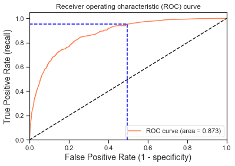

```
Using a threshold of 0.053 guarantees a sensitivity of 0.951 and a specificity of 0.505, i.e. a false positive rate of 49.48%.
============================== GradientBoosting Model Ends ==============================


============================== AdaBoosting Model Starts ==============================
Index(['age', 'job', 'balance', 'day', 'month', 'duration', 'campaign',
       'previous', 'poutcome', 'Target'],
      dtype='object')
Train-set confusion matrix:
 [[30885  1052]
 [ 2772  1459]]
============================== AdaBoosting Model Evaluation ==============================
Accuracy score:
 0.8916288842198385
Test-set confusion matrix:
 [[7700  285]
 [ 695  363]]
Classification report:
               precision    recall  f1-score   support

           0       0.92      0.96      0.94      7985
           1       0.56      0.34      0.43      1058

   micro avg       0.89      0.89      0.89      9043
   macro avg       0.74      0.65      0.68      9043
weighted avg       0.88      0.89      0.88      9043

ROC AUC: 0.8811070615627364
```

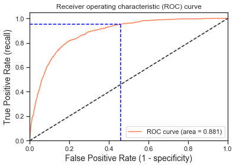

```
Using a threshold of 0.460 guarantees a sensitivity of 0.952 and a specificity of 0.542, i.e. a false positive rate of 45.85%.
============================== AdaBoosting Model Ends ==============================
```

```python
drop_list = ['default','contact','loan','marital','education','housing']
#to drop columns not affecting the model output

models = []

models.append(('GradientBoosting', GradientBoostingClassifier(n_estimators=20, max_depth=3)))
models.append(('AdaBoosting', AdaBoostClassifier(n_estimators=20)))

for i,v in models:
    print('============================== {} Model Starts =============================='.format(i))
    X_train, X_test, y_train, y_test = split_data(dfTransformed, drop_list)
    y_pred, y_pred_prob = get_predictions(v, X_train, y_train, X_test)
    print('============================== {} Model Evaluation =============================='.format(i))
    print_scores(y_test,y_pred,y_pred_prob)
    [fpr, tpr, thr] = roc_curve(y_test, y_pred_prob[:,1])
    roc_curve_draw(fpr, tpr, thr)
    print('============================== {} Model Ends =============================='.format(i))
    print('\n')
```

**Summary Report After Removing Columsn from the Feautre Importance List**

Ada Boosting performs well again with amost same ROC = 88%.

Decision tree and random forest performed worst, with recall almost = 1.00